# Practical Machine Learing

Dhiraj Deshmukh

October 15, 2017

# Required libraries

```r
library(knitr)
library(rpart)
library(randomForest)
```

```r
library(rpart.plot)
library(rattle)
library(caret)
library(gridExtra)
library(RColorBrewer)
```

# Getting and loading data

```r
set.seed(12345)
trainUrl <- "http://d396qusza40orc.cloudfront.net/predmachlearn/pml-training.csv"
testUrl <- "http://d396qusza40orc.cloudfront.net/predmachlearn/pml-testing.csv"
training <- read.csv(url(trainUrl), na.strings=c("NA","#DIV/0!",""))
testing <- read.csv(url(testUrl), na.strings=c("NA","#DIV/0!",""))
```

# Cleaning the data set

#### Provided data has many variables with missing data and the information that is not required for this project. Relevant variables are extracted using pattern recognition for relevant strings, leaving 52 variables.

## Cleaning up Training Data Set

```r
trainingaccel<-grepl("^accel",names(training))
trainingtotal<-grepl("^total",names(training))
roll<-grepl("^roll",names(training))
pitch<-grepl("^pitch",names(training))
yaw<-grepl("^yaw",names(training))
magnet<-grepl("^magnet",names(training))
gyro<-grepl("^gyro",names(training))
acceldata<-training[ ,trainingaccel]
rolldata<-training[ ,roll]
pitchdata<-training[ ,pitch]
yawdata<-training[,yaw]
magnetdata<-training[,magnet]
gyrodata<-training[,gyro]
totaldata<-training[,trainingtotal]
trainClasse<-cbind(acceldata,rolldata,pitchdata,yawdata,magnetdata,gyrodata,totaldata,training[ ,160])
colnames(trainClasse)[53]<-'Classe'
```

## Cleaning up Testing Data Set

```r
testingaccel<-grepl("^accel",names(testing))
testingtotal<-grepl("^total",names(testing))
troll<-grepl("^roll",names(testing))
tpitch<-grepl("^pitch",names(testing))
tyaw<-grepl("^yaw",names(testing))
tmagnet<-grepl("^magnet",names(testing))
tgyro<-grepl("^gyro",names(testing))
tacceldata<-testing[ ,testingaccel]
trolldata<-testing[ ,troll]
tpitchdata<-testing[,tpitch]
tyawdata<-testing[,tyaw]
tmagnetdata<-testing[,tmagnet]
tgyrodata<-testing[,tgyro]
ttotaldata<-testing[,testingtotal]
testClasse<-cbind(tacceldata,trolldata,tpitchdata,tyawdata,tmagnetdata,tgyrodata,ttotaldata,testing[ ,160])
colnames(testClasse)[53]<-'problem.id'
```

# Create Training & Testing Data Subset

#### A training subset is created with 60% of original training data set to be used for training

#### and remaining 40% to be used for testing.

```r
set.seed(400)
inTrain = createDataPartition(trainClasse$Classe, p = .60)[[1]]
trainingsubset = trainClasse[ inTrain,]
testingsubset = trainClasse[-inTrain,]
```

# rpart Model

### Decision tree, the first model tested using rpart

```r
set.seed(400)
modFit<-train(Classe~.,method="rpart", data=trainingsubset)
print(modFit$finalModel)
```

```
## n= 11776
##
## node), split, n, loss, yval, (yprob)
##       * denotes terminal node
##
##   1) root 11776 8428 A (0.28 0.19 0.17 0.16 0.18)
##     2) roll_belt< 130.5 10776 7437 A (0.31 0.21 0.19 0.18 0.11)
##       4) pitch_forearm< -33.95 944    5 A (0.99 0.0053 0 0 0) *
##       5) pitch_forearm>=-33.95 9832 7432 A (0.24 0.23 0.21 0.2 0.12)
##        10) yaw_belt>=169.5 507   55 A (0.89 0.049 0 0.053 0.0059) *
##        11) yaw_belt< 169.5 9325 7076 B (0.21 0.24 0.22 0.2 0.13)
##          22) magnet_dumbbell_z< -88.5 1218  519 A (0.57 0.28 0.047 0.072 0.026) *
##          23) magnet_dumbbell_z>=-88.5 8107 6110 C (0.15 0.24 0.25 0.22 0.14)
##            46) pitch_belt< -42.95 496   83 B (0.014 0.83 0.1 0.022 0.028) *
##            47) pitch_belt>=-42.95 7611 5665 C (0.16 0.2 0.26 0.24 0.15)
##              94) magnet_dumbbell_x>=-446.5 3261 2281 B (0.17 0.3 0.094 0.24 0.2)
##               188) roll_belt< 117.5 2049 1175 B (0.17 0.43 0.024 0.13 0.25) *
##               189) roll_belt>=117.5 1212  699 D (0.17 0.087 0.21 0.42 0.11) *
##              95) magnet_dumbbell_x< -446.5 4350 2710 C (0.16 0.12 0.38 0.23 0.11) *
##     3) roll_belt>=130.5 1000    9 E (0.009 0 0 0 0.99) *
```

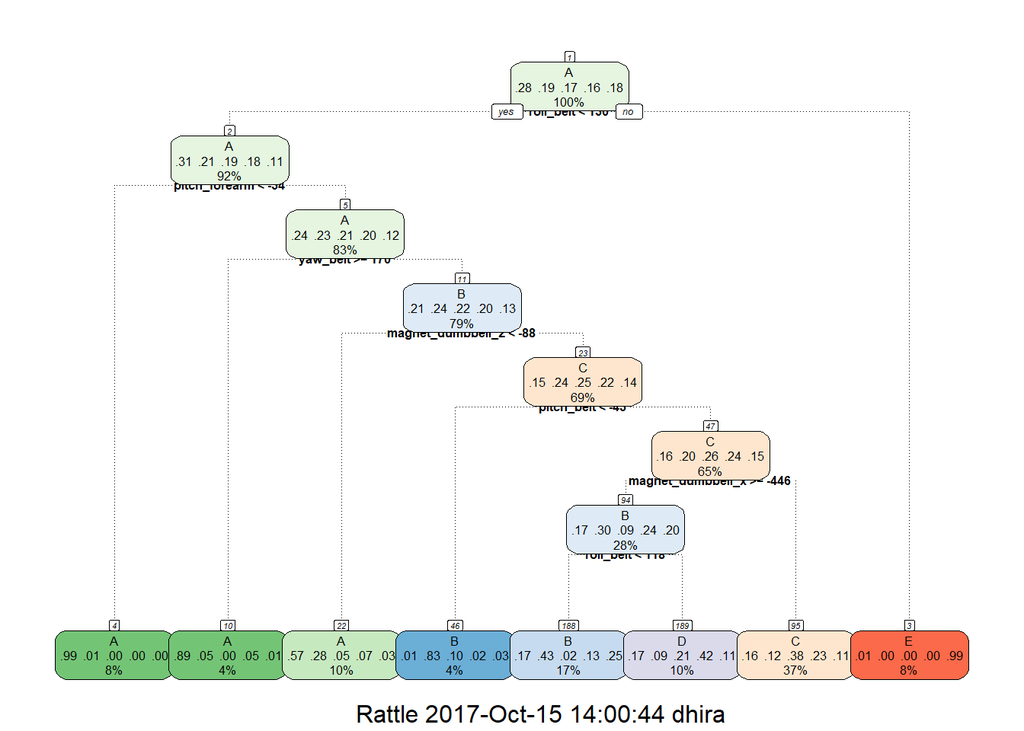

```r
fancyRpartPlot(modFit$finalModel,cex=.5,under.cex=1,shadow.offset=0)
```

```r
classepredict=predict(modFit,testingsubset)
confusionMatrix(testingsubset$Classe,classepredict)
```

```
## Confusion Matrix and Statistics
##
##           Reference
## Prediction    A    B    C    D    E
##          A 1349  233  479  166    5
##          B  247  864  337   70    0
##          C   41   55 1078  194    0
##          D   72  183  679  352    0
##          E   19  355  360   68  640
##
## Overall Statistics
##
##                Accuracy : 0.5459
##                  95% CI : (0.5348, 0.5569)
##     No Information Rate : 0.3738
##     P-Value [Acc > NIR] : < 2.2e-16
##
##                   Kappa : 0.4307
##  Mcnemar's Test P-Value : < 2.2e-16
##
## Statistics by Class:
##
##                      Class: A Class: B Class: C Class: D Class: E
## Sensitivity            0.7807   0.5112   0.3675  0.41412  0.99225
## Specificity            0.8557   0.8938   0.9410  0.86650  0.88863
## Pos Pred Value         0.6044   0.5692   0.7880  0.27372  0.44383
## Neg Pred Value         0.9325   0.8695   0.7136  0.92409  0.99922
## Prevalence             0.2202   0.2154   0.3738  0.10834  0.08221
## Detection Rate         0.1719   0.1101   0.1374  0.04486  0.08157
## Detection Prevalence   0.2845   0.1935   0.1744  0.16391  0.18379
## Balanced Accuracy      0.8182   0.7025   0.6543  0.64031  0.94044
```

#### Rpart model shows that it is 54.6% accurate only. oll_belt, pitch_forearm, yaw_belt,magnet_dumbbell_Z,pitch_belt, and magnet_dumbell_x are the variables used in the algorithm. And the model is least accurate for outcome D.

# Random Forest Model

#### As we have seen that the rpart model wasnt that accurate, next Random forest model will be used to see how accurate it fits the data into.

```r
set.seed(400)
modFit2 <- train(Classe ~ ., method="rf",trControl=trainControl(method = "cv", number = 4), data=trainingsubset)
print(modFit2)
```

```
## Random Forest
##
## 11776 samples
##    52 predictor
##     5 classes: 'A', 'B', 'C', 'D', 'E'
##
## No pre-processing
## Resampling: Cross-Validated (4 fold)
## Summary of sample sizes: 8830, 8834, 8833, 8831
## Resampling results across tuning parameters:
##
##   mtry  Accuracy   Kappa
##    2    0.9881968  0.9850680
##   27    0.9881111  0.9849582
##   52    0.9844597  0.9803386
##
## Accuracy was used to select the optimal model using  the largest value.
## The final value used for the model was mtry = 2.
```

```r
varImp(modFit2)
```

```
## rf variable importance
##
##   only 20 most important variables shown (out of 52)
##
##                      Overall
## roll_belt             100.00
## yaw_belt               83.26
## magnet_dumbbell_z      69.88
## magnet_dumbbell_y      64.76
## pitch_belt             61.84
## pitch_forearm          59.44
## magnet_dumbbell_x      51.73
## roll_forearm           47.42
## magnet_belt_z          46.52
## accel_belt_z           43.44
## accel_dumbbell_y       42.27
## roll_dumbbell          41.87
## magnet_belt_y          39.67
## accel_dumbbell_z       36.59
## roll_arm               33.24
## accel_forearm_x        31.57
## magnet_arm_x           29.88
## accel_dumbbell_x       29.65
## yaw_dumbbell           28.83
## total_accel_dumbbell   28.11
```

```r
classepredict2=predict(modFit2,testingsubset)
confusionMatrix(testingsubset$Classe,classepredict2)
```

```
## Confusion Matrix and Statistics
##
##           Reference
## Prediction    A    B    C    D    E
##          A 2232    0    0    0    0
##          B    8 1497   13    0    0
##          C    0   16 1349    3    0
##          D    0    0   23 1263    0
##          E    0    0    5    1 1436
##
## Overall Statistics
##
##                Accuracy : 0.9912
##                  95% CI : (0.9889, 0.9932)
##     No Information Rate : 0.2855
##     P-Value [Acc > NIR] : < 2.2e-16
##
##                   Kappa : 0.9889
##  Mcnemar's Test P-Value : NA
##
## Statistics by Class:
##
##                      Class: A Class: B Class: C Class: D Class: E
## Sensitivity            0.9964   0.9894   0.9705   0.9968   1.0000
## Specificity            1.0000   0.9967   0.9971   0.9965   0.9991
## Pos Pred Value         1.0000   0.9862   0.9861   0.9821   0.9958
## Neg Pred Value         0.9986   0.9975   0.9937   0.9994   1.0000
## Prevalence             0.2855   0.1928   0.1772   0.1615   0.1830
## Detection Rate         0.2845   0.1908   0.1719   0.1610   0.1830
## Detection Prevalence   0.2845   0.1935   0.1744   0.1639   0.1838
## Balanced Accuracy      0.9982   0.9931   0.9838   0.9967   0.9995
```

#### Random forest model found to be more accurate, around 99.2%, than the rpart model. The most important variables includes roll_belt, yaw_belt,magnet_dumbbell_z,magnet_dumbbell_y, and pitch_forearm. Though it is least accurate model C.

#### Using qplot the more detailed graph is shown compared to rpart model.

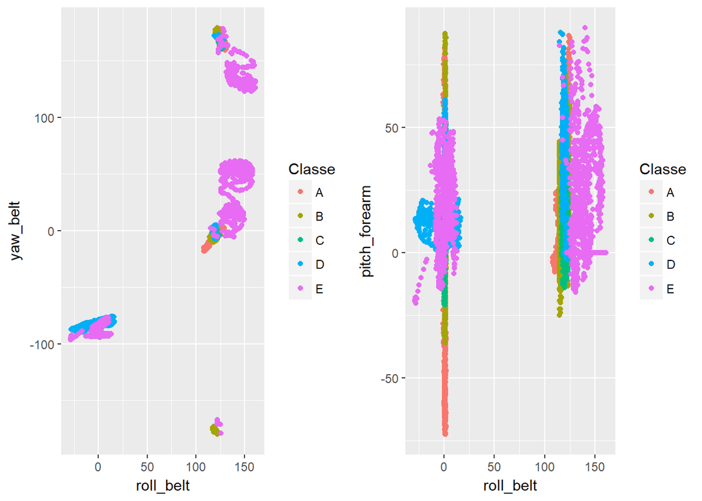

```r
p1<-qplot(roll_belt,yaw_belt,colour=Classe,data=trainingsubset)
p2<-qplot(roll_belt,pitch_forearm,colour=Classe,data=trainingsubset)
grid.arrange(p1,p2,ncol=2)
```

```r
dev.off()
```

# Sample Out Of Error

```r
insamplepredict=predict(modFit2,trainingsubset)
confusionMatrix(trainingsubset$Classe,insamplepredict)
```

```
## Confusion Matrix and Statistics
##
##           Reference
## Prediction    A    B    C    D    E
##          A 3348    0    0    0    0
##          B    0 2279    0    0    0
##          C    0    0 2054    0    0
##          D    0    0    0 1930    0
##          E    0    0    0    0 2165
##
## Overall Statistics
##
##                Accuracy : 1
##                  95% CI : (0.9997, 1)
##     No Information Rate : 0.2843
##     P-Value [Acc > NIR] : < 2.2e-16
##
##                   Kappa : 1
##  Mcnemar's Test P-Value : NA
##
## Statistics by Class:
##
##                      Class: A Class: B Class: C Class: D Class: E
## Sensitivity            1.0000   1.0000   1.0000   1.0000   1.0000
## Specificity            1.0000   1.0000   1.0000   1.0000   1.0000
## Pos Pred Value         1.0000   1.0000   1.0000   1.0000   1.0000
## Neg Pred Value         1.0000   1.0000   1.0000   1.0000   1.0000
## Prevalence             0.2843   0.1935   0.1744   0.1639   0.1838
## Detection Rate         0.2843   0.1935   0.1744   0.1639   0.1838
## Detection Prevalence   0.2843   0.1935   0.1744   0.1639   0.1838
## Balanced Accuracy      1.0000   1.0000   1.0000   1.0000   1.0000
```

#### It is shown how the model shows the accuracy of99.2% when used with different data set

```r
classepredict2=predict(modFit2,testingsubset)
confusionMatrix(testingsubset$Classe,classepredict2)
```

```
## Confusion Matrix and Statistics
##
##           Reference
## Prediction    A    B    C    D    E
##          A 2232    0    0    0    0
##          B    8 1497   13    0    0
##          C    0   16 1349    3    0
##          D    0    0   23 1263    0
##          E    0    0    5    1 1436
##
## Overall Statistics
##
##                Accuracy : 0.9912
##                  95% CI : (0.9889, 0.9932)
##     No Information Rate : 0.2855
##     P-Value [Acc > NIR] : < 2.2e-16
##
##                   Kappa : 0.9889
##  Mcnemar's Test P-Value : NA
##
## Statistics by Class:
##
##                      Class: A Class: B Class: C Class: D Class: E
## Sensitivity            0.9964   0.9894   0.9705   0.9968   1.0000
## Specificity            1.0000   0.9967   0.9971   0.9965   0.9991
## Pos Pred Value         1.0000   0.9862   0.9861   0.9821   0.9958
## Neg Pred Value         0.9986   0.9975   0.9937   0.9994   1.0000
## Prevalence             0.2855   0.1928   0.1772   0.1615   0.1830
## Detection Rate         0.2845   0.1908   0.1719   0.1610   0.1830
## Detection Prevalence   0.2845   0.1935   0.1744   0.1639   0.1838
## Balanced Accuracy      0.9982   0.9931   0.9838   0.9967   0.9995
```

```r
testinganswers=predict(modFit2, newdata=testing)
print(testinganswers)
```

```
##  [1] B A B A A E D B A A B C B A E E A B B B
## Levels: A B C D E
```

#### Please note that all samples were taken from one larger sample. And the data that was collected, if it is collected again, it is possible that the out of sample erroe could be higher. As this is the data set for 6 people only, so it can not be generalised for the whole population.

# Summary

#### Random Forest Model was better than the Rpart Model. It was 99.2% accurate and fitted well with the data set, but algorithm may not be that accurate. In Rpart model, D was most difficult to predict and in Random Forest, C was hard to predict. It is fun to see how the exercise and its quality can change the monitors and the monitors can predict the errors made during the exercise. So it can be concluded as the most important model which measures and analyze the quality of exercise and can help people to make their health better.